# MAST6100 - Computing Session Week 3

# Wells in Bangladesh Data

Load the data:

```r
wells <- read.csv("wells.csv", header = TRUE)
```

## Explore the Response Variable

### Frequency Table

0 - don’t switch wells 1 - do switch wells

```r
table(wells$switch)
```

```
   0    1
1283 1737
```

### Proportions

```r
library(janitor)

tabyl(wells, switch)
```

```
 switch    n   percent
      0 1283 0.4248344
      1 1737 0.5751656
```

## 42% don’t, 58% do

## Logistic Regression with Distance

Fit a logistic regression model with:

- Response: `switch`
- Predictor: `dist`

As before, R will automatically include an intercept term (β0), and the names of the variables in the dataframe are used in the regression equation.

• The second argument family tells which family of GLM’s you want to use. For logistic model, you will always use family = binomial. • The third argument data tells R which data frame to use.

```r
fit_wells <- glm(
  switch ~ dist,
  family = binomial,
  data = wells
)

summary(fit_wells)
```

```
Call:
glm(formula = switch ~ dist, family = binomial, data = wells)

Coefficients:
              Estimate Std. Error z value Pr(>|z|)
(Intercept)  0.6059594  0.0603102  10.047  < 2e-16 ***
dist        -0.0062188  0.0009743  -6.383 1.74e-10 ***
---
Signif. codes:  0 ‘***’ 0.001 ‘**’ 0.01 ‘*’ 0.05 ‘.’ 0.1 ‘ ’ 1

(Dispersion parameter for binomial family taken to be 1)

    Null deviance: 4118.1  on 3019  degrees of freedom
Residual deviance: 4076.2  on 3018  degrees of freedom
AIC: 4080.2

Number of Fisher Scoring iterations: 4
```

Distance negatively impacts the probability of switching

### Model Equation

Write the model in the form

$$\log\left(\frac{\pi}{1-\pi}\right)
=
\beta_0+\beta_1(dist)$$

### Question

According to this summary, is the effect of distance of a safe is significant to explain the probability of switching to a new well? Yes, as the p-value for this variable is less than 0.05.

## Logistic Regression with Arsenic

Do the same analysis using the variable arsenic. We can fit the model with the following command

```r
fit_wells2 <- glm(
  switch ~ arsenic,
  family = binomial,
  data = wells
)

summary(fit_wells2)
```

```
Call:
glm(formula = switch ~ arsenic, family = binomial, data = wells)

Coefficients:
            Estimate Std. Error z value Pr(>|z|)
(Intercept) -0.30553    0.07030  -4.346 1.39e-05 ***
arsenic      0.37914    0.03853   9.840  < 2e-16 ***
---
Signif. codes:  0 ‘***’ 0.001 ‘**’ 0.01 ‘*’ 0.05 ‘.’ 0.1 ‘ ’ 1

(Dispersion parameter for binomial family taken to be 1)

    Null deviance: 4118.1  on 3019  degrees of freedom
Residual deviance: 4008.7  on 3018  degrees of freedom
AIC: 4012.7

Number of Fisher Scoring iterations: 4
```

### Question

As the summary suggest, arsenic is also important to explain the probability of switching to a new well (p<0.05)

# Titanic Data

Load the data: You have a variable survived that is equal to 1 if the person survived and 0 otherwise

```r
titanic <- read.csv("titanic.csv")
```

## Question 1

Create a contingency table for:

- Sex
- Survival (0 - no, 1 - yes)

The table can created with the following command

```r
table(titanic$sex, titanic$survived)
```

```
            0    1
  Female  126  344
  Male   1364  367
```

### Survival Proportions by Sex

Based on this table, answer whether you expect that the probability of surviving given that you were a male is higher or lower than the probability of surviving given that you were a female. Explain why.

The probability of females should be higher as the proportion of females who survived the accident is much higher than the proportion of males. We can check with the following command

```r
prop.table(
  table(titanic$sex, titanic$survived),
  1
)
```

```
                 0         1
  Female 0.2680851 0.7319149
  Male   0.7879838 0.2120162
```

## Question 2

Repeat the analysis for Age.

### Survival Proportions by Age

We can check the proportion of adults and children who survived in the following way.

```r
prop.table(
  table(titanic$age, titanic$survived),
  1
)
```

```
                0         1
  Adult 0.6873805 0.3126195
  Child 0.4770642 0.5229358
```

## Based on this table, we can answer that the probability of surviving is much higher for children

## Question 3

```r
titanic_model1 <- glm(
  survived ~ sex,
  data = titanic
)

summary(titanic_model1)
```

```
Call:
glm(formula = survived ~ sex, data = titanic)

Coefficients:
            Estimate Std. Error t value Pr(>|t|)
(Intercept)  0.73191    0.01921    38.1   <2e-16 ***
sexMale     -0.51990    0.02166   -24.0   <2e-16 ***
---
Signif. codes:  0 ‘***’ 0.001 ‘**’ 0.01 ‘*’ 0.05 ‘.’ 0.1 ‘ ’ 1

(Dispersion parameter for gaussian family taken to be 0.1734476)

    Null deviance: 481.32  on 2200  degrees of freedom
Residual deviance: 381.41  on 2199  degrees of freedom
AIC: 2394.3

Number of Fisher Scoring iterations: 2
```

```r
exp(coef(titanic_model1))
```

```
(Intercept)     sexMale
  2.0790580   0.5945808
```

Does this model matches your initial analysis of the association between sex and probability of surviving the accident.

## Question 4

```r
titanic_model2 <- glm(
  survived ~ age,
  data = titanic
)

summary(titanic_model2)
```

```
Call:
glm(formula = survived ~ age, data = titanic)

Coefficients:
            Estimate Std. Error t value Pr(>|t|)
(Intercept)  0.31262    0.01018  30.709  < 2e-16 ***
ageChild     0.21032    0.04575   4.598 4.52e-06 ***
---
Signif. codes:  0 ‘***’ 0.001 ‘**’ 0.01 ‘*’ 0.05 ‘.’ 0.1 ‘ ’ 1

(Dispersion parameter for gaussian family taken to be 0.2167983)

    Null deviance: 481.32  on 2200  degrees of freedom
Residual deviance: 476.74  on 2199  degrees of freedom
AIC: 2885.3

Number of Fisher Scoring iterations: 2
```

```r
exp(coef(titanic_model2))
```

```
(Intercept)    ageChild
   1.367001    1.234068
```

# Price in Restaurants

Load the data:

```r
nyc <- read.csv("nyc.csv")
```

## Question 1

Create a binary variable that equals:

- 1 if Price > 40
- 0 otherwise

```r
nyc$price_binary <- ifelse(
  nyc$Price > 40,
  1,
  0
)
```

### Frequency Table

```r
table(nyc$price_binary)
```

```
 0  1
72 96
```

We can see that there are 72 restaurants with prices less than £40 and 96 restaurants with prices more than £40.

## Question 2

Investigate whether Food, Decor and Service may explain the probability that a restaurant costs more than $40. We can create the plots with the following commands.

### Food

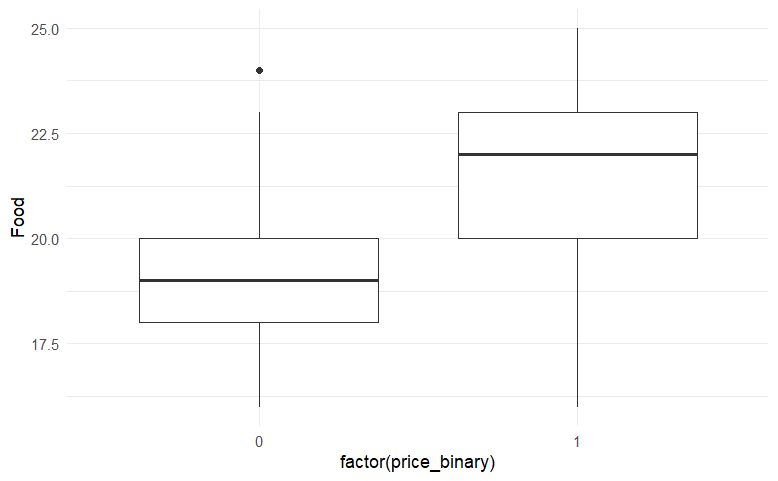

```r
library(ggplot2)

ggplot(nyc) +
  theme_minimal() +
  geom_boxplot(
    aes(
      y = Food,
      x = factor(price_binary)
    )
  )
```

### Decor

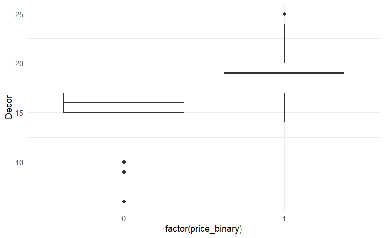

```r
ggplot(nyc) +
  theme_minimal() +
  geom_boxplot(
    aes(
      y = Decor,
      x = factor(price_binary)
    )
  )
```

### Service

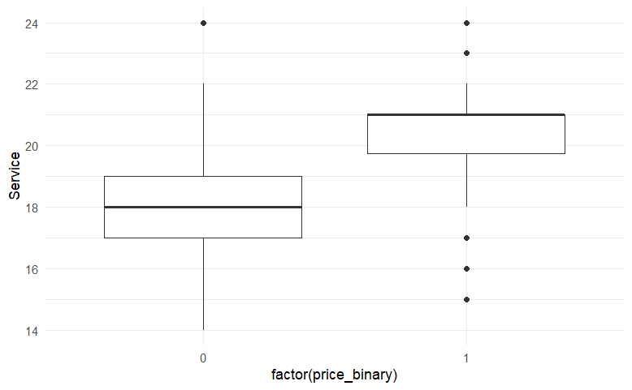

```r
ggplot(nyc) +
  theme_minimal() +
  geom_boxplot(
    aes(
      y = Service,
      x = factor(price_binary)
    )
  )
```

Make this plot for variables Food, Decor and Service. What do these plots show? All the three plots show that increasing the rates of either Food, Decor and Service should increase the probability of observing a restaurant with price over $40.

## Question 3

Fit logistic regression models with `price_binary` as the response.

### (i) Food as Predictor

```r
model_nyc1 <- glm(
  price_binary ~ Food,
  data = nyc,
  family = binomial
)

summary(model_nyc1)
```

```
Call:
glm(formula = price_binary ~ Food, family = binomial, data = nyc)

Coefficients:
            Estimate Std. Error z value Pr(>|z|)
(Intercept) -14.2446     2.4112  -5.908 3.47e-09 ***
Food          0.7115     0.1185   6.004 1.92e-09 ***
---
Signif. codes:  0 ‘***’ 0.001 ‘**’ 0.01 ‘*’ 0.05 ‘.’ 0.1 ‘ ’ 1

(Dispersion parameter for binomial family taken to be 1)

    Null deviance: 229.46  on 167  degrees of freedom
Residual deviance: 176.04  on 166  degrees of freedom
AIC: 180.04

Number of Fisher Scoring iterations: 4
```

### Model Equation

Write the fitted equation:

$$\log\left(\frac{\pi}{1-\pi}\right)
=
\beta_0+\beta_1(Food)$$

### Predicted Probability when Food = 22

What is the probability of a restaurant having its price higher than $40 when the rating of Food is equal to 22?

```r
predict(
  model_nyc1,
  newdata = data.frame(Food = 22),
  type = "response"
)
```

```
        1
0.8036817
```

Alternatively:

```r
exp(-14.24 + 0.71*22) /
(1 + exp(-14.24 + 0.71*22))
```

```
[1] 0.798991
```

### (ii) Decor as Predictor

With Decor as your explanatory variable. Write your obtained regression equation

```r
model_nyc2 <- glm(
  price_binary ~ Decor,
  data = nyc,
  family = binomial
)

summary(model_nyc2)
```

```
Call:
glm(formula = price_binary ~ Decor, family = binomial, data = nyc)

Coefficients:
            Estimate Std. Error z value Pr(>|z|)
(Intercept) -12.1867     2.0424  -5.967 2.42e-09 ***
Decor         0.7137     0.1174   6.079 1.21e-09 ***
---
Signif. codes:  0 ‘***’ 0.001 ‘**’ 0.01 ‘*’ 0.05 ‘.’ 0.1 ‘ ’ 1

(Dispersion parameter for binomial family taken to be 1)

    Null deviance: 229.46  on 167  degrees of freedom
Residual deviance: 162.68  on 166  degrees of freedom
AIC: 166.68

Number of Fisher Scoring iterations: 5
```

### Model Equation

Write the fitted equation:

$$\log\left(\frac{\pi}{1-\pi}\right)
=
\beta_0+\beta_1(Decor)$$

### Predicted Probability when Decor = 22

```r
predict(
  model_nyc2,
  newdata = data.frame(Decor = 22),
  type = "response"
)
```

```
        1
0.9710976
```

Alternatively:

```r
exp(-12.19 + 0.71*22) /
(1 + exp(-12.19 + 0.71*22))
```

```
[1] 0.9686291
```

Interpret the probability.

# Wells in Bangladesh Data

Load the data:

```r
wells <- read.csv("wells.csv", header = TRUE)
```

## Question 1

Fit a logistic regression model with:

- Response: `switch`
- Predictors: `arsenic`, `dist`, `assoc`, `educ`

```r
fit_wells <- glm(
  switch ~ dist + arsenic + assoc + educ,
  family = binomial,
  data = wells
)

summary(fit_wells)
```

```
Call:
glm(formula = switch ~ dist + arsenic + assoc + educ, family = binomial,
    data = wells)

Coefficients:
             Estimate Std. Error z value Pr(>|z|)
(Intercept) -0.156712   0.099601  -1.573    0.116
dist        -0.008961   0.001046  -8.569  < 2e-16 ***
arsenic      0.467022   0.041602  11.226  < 2e-16 ***
assoc       -0.124300   0.076966  -1.615    0.106
educ         0.042447   0.009588   4.427 9.55e-06 ***
---
Signif. codes:  0 ‘***’ 0.001 ‘**’ 0.01 ‘*’ 0.05 ‘.’ 0.1 ‘ ’ 1

(Dispersion parameter for binomial family taken to be 1)

    Null deviance: 4118.1  on 3019  degrees of freedom
Residual deviance: 3907.8  on 3015  degrees of freedom
AIC: 3917.8

Number of Fisher Scoring iterations: 4
```

### Write the Model Equation

Use the coefficient estimates from the output to write:

$$\log\left(\frac{\pi_i}{1-\pi_i}\right)
=
\beta_0 + \beta_1(dist) + \beta_2(arsenic) + \beta_3(assoc) +
\beta_4(educ)$$

## Question 2

Can we say that assoc is an important variable to explain the probability of switching to a new well? Explain why. If we consider a significance level of 5%, then assoc should not be considered an important variable to explain the probability of switching to a new well. This is true because the p-value associated with this variable is larger than 5%

## Question 3

What is the effect of education on the probabilities of switching to a new well? If we increase the education level by one year, we estimate that the odds of switching to a new well is 1.04 times the odds of someone with 1 year less of educational level, when we consider all the other variables constant

Use the estimated coefficient and odds ratio.

```r
exp(coef(fit_wells)["educ"])
```

```
   educ
1.04336
```

## Question 4

Similarly to linear models, we can use the predict function to obtain predictions from our models. We just need to use the argument type = ‘response’ in order to get the estimated probabilities. For instance,

### Example

```r
model <- glm(
  switch ~ arsenic + dist + assoc + educ,
  data = wells,
  family = binomial
)

predict(
  model,
  newdata = data.frame(
    arsenic = 2,
    dist = 50,
    assoc = 1,
    educ = 10
  ),
  type = "response"
)
```

```
        1
0.6523631
```

Find the estimated probability for:

- arsenic = 2
- dist = 150
- assoc = 1
- educ = 10

```r
predict(
  model,
  newdata = data.frame(
    arsenic = 2,
    dist = 150,
    assoc = 1,
    educ = 10
  ),
  type = "response"
)
```

```
        1
0.4337254
```

# Titanic Data

For this example, we are going to continue looking at data from the Titanic crash. You have a variable survived that is equal to 1 if the person survived and 0 otherwise

```r
titanic <- read.csv("titanic.csv")
```

## Question 1

Fit a logistic regression model with survived as your response variable and all other variable as covariates. We can fit the model with the following command

```r
model_titanic <- glm(
  survived ~ .,
  data = titanic,
  family = binomial
)

summary(model_titanic)
```

```
Call:
glm(formula = survived ~ ., family = binomial, data = titanic)

Coefficients:
            Estimate Std. Error z value Pr(>|z|)
(Intercept)   2.0438     0.1679  12.171  < 2e-16 ***
class2nd     -1.0181     0.1960  -5.194 2.05e-07 ***
class3rd     -1.7778     0.1716 -10.362  < 2e-16 ***
classCrew    -0.8577     0.1573  -5.451 5.00e-08 ***
sexMale      -2.4201     0.1404 -17.236  < 2e-16 ***
ageChild      1.0615     0.2440   4.350 1.36e-05 ***
---
Signif. codes:  0 ‘***’ 0.001 ‘**’ 0.01 ‘*’ 0.05 ‘.’ 0.1 ‘ ’ 1

(Dispersion parameter for binomial family taken to be 1)

    Null deviance: 2769.5  on 2200  degrees of freedom
Residual deviance: 2210.1  on 2195  degrees of freedom
AIC: 2222.1

Number of Fisher Scoring iterations: 4
```

### Write the Model Equation

Use the coefficient estimates to write:

$$\log\left(\frac{\pi}{1-\pi}\right)
=
\beta_0
+\beta_1(class2nd)
+\beta_2(class3rd)
+\beta_3(classCrew)
+\beta_4(sexMale)
+\beta_5(ageChild)$$

### Interpret the Variables

Explain the effect of:

- The odds of surviving between someone in the 2nd class is 0.36 times the odds of surviving in the 1st.
- The odds of surviving between someone in the 3nd class is 0.17 times the odds of surviving in the 1st.
- The odds of surviving between someone being part of the Crew is 0.42 times the odds of surviving in the 1st.
- The odds of surviving between some male person is 0.09 times the odds of surviving being a female.
- The odds of surviving between some child is 2.89 times the odds of surviving being an adult.

Useful code:

```r
exp(coef(model_titanic))
```

```
(Intercept)    class2nd    class3rd   classCrew     sexMale    ageChild
 7.72017801  0.36128255  0.16901595  0.42414659  0.08891625  2.89082629
```

## Question 2

Compare the estimated probabilities of survival for the following passengers.

### Female, Child, 1st Class

```r
predict(
  model_titanic,
  newdata = data.frame(
    sex = "Female",
    class = "1st",
    age = "Child"
  ),
  type = "response"
)
```

```
        1
0.9571141
```

### Male, Adult, 3rd Class

```r
predict(
  model_titanic,
  newdata = data.frame(
    sex = "Male",
    class = "3rd",
    age = "Adult"
  ),
  type = "response"
)
```

```
        1
0.1039594
```

Female, 1st class children have a higher probability to survive than Male, 3rd class Adults. 0.95 vs 0.10

## All Possible Scenarios

Create every combination of the predictor variables and calculate predicted probabilities.

```r
all_possible_scenarios <- expand.grid(
  sex = c("Male", "Female"),
  age = c("Child", "Adult"),
  class = c("1st", "2nd", "3rd", "Crew")
)

all_possible_scenarios$prob <- predict(
  model_titanic,
  newdata = all_possible_scenarios,
  type = "response"
)

all_possible_scenarios
```

| sex | age | class | prob |
| --- | --- | --- | --- |
| Male | Child | 1st | 0.6649249 |
| Female | Child | 1st | 0.9571141 |
| Male | Adult | 1st | 0.4070382 |
| Female | Adult | 1st | 0.8853234 |
| Male | Child | 2nd | 0.4175655 |
| Female | Child | 2nd | 0.8896612 |
| Male | Adult | 2nd | 0.1987193 |
| Female | Adult | 2nd | 0.7360897 |
| Male | Child | 3rd | 0.2511586 |
| Female | Child | 3rd | 0.7904463 |

[output cut: 6 more lines]

## Visualisation

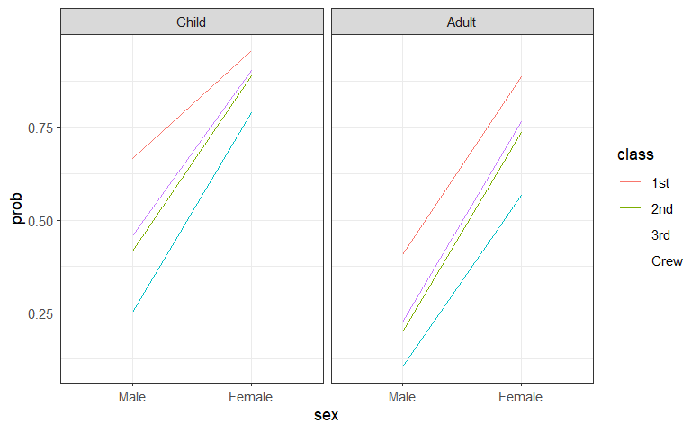

```r
library(ggplot2)

ggplot(all_possible_scenarios) +
  geom_line(
    aes(
      x = sex,
      y = prob,
      colour = class,
      group = class
    )
  ) +
  facet_wrap(~ age) +
  theme_bw()
```

# 1. Wells in Bangladesh Data

Load the data:

```r
wells <- read.csv("wells.csv", header = TRUE)
library(hnp)
library(MASS)
```

## Question 1

Consider a logistic regression model with `switch` as the response variable.

### (a) Predictor: dist

We can fit the model with the following code

```
Binomial model
```

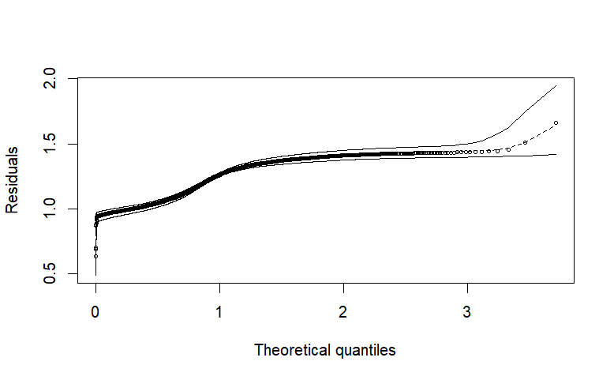

```r
model_dist <- glm(switch ~ dist,
                  data = wells,
                  family = binomial)

hnp(model_dist)
```

### (b) Predictor: arsenic

```
Binomial model
```

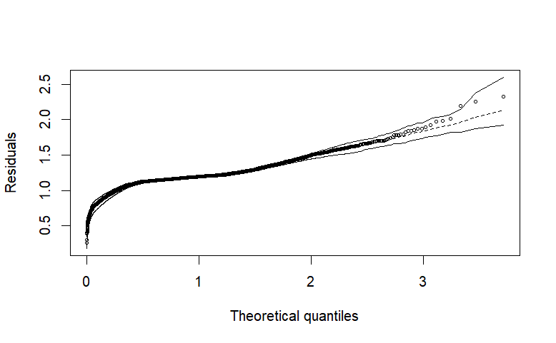

```r
model_arsenic <- glm(switch ~ arsenic,
                     data = wells,
                     family = binomial)

hnp(model_arsenic)
```

### (c) Predictors: dist and arsenic

```
Binomial model
```

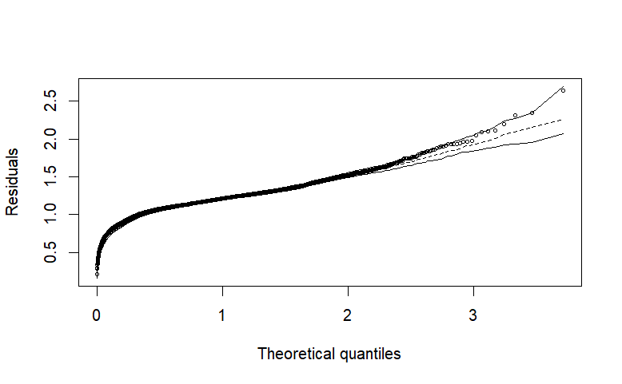

```r
model_twovar <- glm(switch ~ dist + arsenic,
                    data = wells,
                    family = binomial)

hnp(model_twovar)
```

### (d) Predictors: dist, arsenic, assoc and educ

```
Binomial model
```

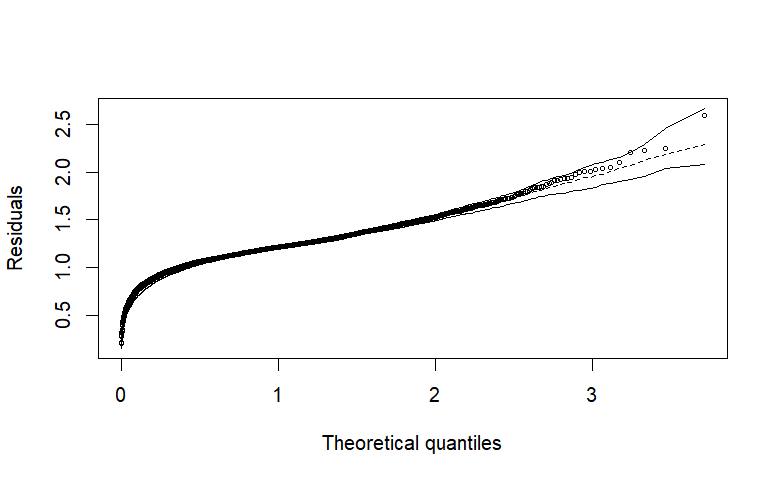

```r
model_fourvar <- glm(switch ~ dist + arsenic + assoc + educ,
                     data = wells,
                     family = binomial)

hnp(model_fourvar)
```

## Question 2

Fit a logistic regression model with interactions between `assoc` and the other numerical variables.Use the function stepAIC to select the model with the lowest AIC. Comment the results. We need to load library MASS to use function stepAIC in order to use it first. Then we can fit the model and use the variable selection with the following codes:

```r
model_to_varselection <- glm(
  switch ~ assoc * (dist + arsenic + educ),
  data = wells,
  family = binomial
)

best_model <- stepAIC(
  model_to_varselection,
  direction = "both"
)
```

```
Start:  AIC=3918.48
switch ~ assoc * (dist + arsenic + educ)

                Df Deviance    AIC
- assoc:dist     1   3903.3 3917.3
- assoc:educ     1   3904.3 3918.3
<none>               3902.5 3918.5
- assoc:arsenic  1   3906.2 3920.2

Step:  AIC=3917.3
switch ~ assoc + dist + arsenic + educ + assoc:arsenic + assoc:educ

                Df Deviance    AIC
- assoc:educ     1   3905.0 3917.0
<none>               3903.3 3917.3
- assoc:arsenic  1   3906.3 3918.3
+ assoc:dist     1   3902.5 3918.5
- dist           1   3979.6 3991.6

Step:  AIC=3917.04
switch ~ assoc + dist + arsenic + educ + assoc:arsenic

                Df Deviance    AIC
<none>               3905.0 3917.0
+ assoc:educ     1   3903.3 3917.3
- assoc:arsenic  1   3907.8 3917.8
+ assoc:dist     1   3904.3 3918.3
- educ           1   3924.8 3934.8
- dist           1   3982.3 3992.3
```

```r
summary(best_model)
```

```
Call:
glm(formula = switch ~ assoc + dist + arsenic + educ + assoc:arsenic,
    family = binomial, data = wells)

Coefficients:
               Estimate Std. Error z value Pr(>|z|)
(Intercept)   -0.246833   0.113593  -2.173   0.0298 *
assoc          0.081079   0.144879   0.560   0.5757
dist          -0.008962   0.001046  -8.564  < 2e-16 ***
arsenic        0.526029   0.055407   9.494  < 2e-16 ***
educ           0.042396   0.009596   4.418 9.97e-06 ***
assoc:arsenic -0.134551   0.080360  -1.674   0.0941 .
---
Signif. codes:  0 ‘***’ 0.001 ‘**’ 0.01 ‘*’ 0.05 ‘.’ 0.1 ‘ ’ 1

(Dispersion parameter for binomial family taken to be 1)

    Null deviance: 4118.1  on 3019  degrees of freedom
Residual deviance: 3905.0  on 3014  degrees of freedom
AIC: 3917

Number of Fisher Scoring iterations: 4
```

### Removing Non-Significant Terms

The model chosen includes an interaction with nonsignificant results. We can exclude that variable manually.

```r
best_model2 <- glm(
  switch ~ assoc + dist + arsenic + educ,
  data = wells,
  family = binomial
)

summary(best_model2)
```

```
Call:
glm(formula = switch ~ assoc + dist + arsenic + educ, family = binomial,
    data = wells)

Coefficients:
             Estimate Std. Error z value Pr(>|z|)
(Intercept) -0.156712   0.099601  -1.573    0.116
assoc       -0.124300   0.076966  -1.615    0.106
dist        -0.008961   0.001046  -8.569  < 2e-16 ***
arsenic      0.467022   0.041602  11.226  < 2e-16 ***
educ         0.042447   0.009588   4.427 9.55e-06 ***
---
Signif. codes:  0 ‘***’ 0.001 ‘**’ 0.01 ‘*’ 0.05 ‘.’ 0.1 ‘ ’ 1

(Dispersion parameter for binomial family taken to be 1)

    Null deviance: 4118.1  on 3019  degrees of freedom
Residual deviance: 3907.8  on 3015  degrees of freedom
AIC: 3917.8

Number of Fisher Scoring iterations: 4
```

And again we still have one variable that it is not significant, so we can remove that variable manually as well.

```r
best_model3 <- glm(
  switch ~ dist + arsenic + educ,
  data = wells,
  family = binomial
)

summary(best_model3)
```

```
Call:
glm(formula = switch ~ dist + arsenic + educ, family = binomial,
    data = wells)

Coefficients:
             Estimate Std. Error z value Pr(>|z|)
(Intercept) -0.213932   0.093113  -2.298   0.0216 *
dist        -0.008956   0.001046  -8.562  < 2e-16 ***
arsenic      0.468364   0.041592  11.261  < 2e-16 ***
educ         0.042820   0.009574   4.472 7.74e-06 ***
---
Signif. codes:  0 ‘***’ 0.001 ‘**’ 0.01 ‘*’ 0.05 ‘.’ 0.1 ‘ ’ 1

(Dispersion parameter for binomial family taken to be 1)

    Null deviance: 4118.1  on 3019  degrees of freedom
Residual deviance: 3910.4  on 3016  degrees of freedom
AIC: 3918.4

Number of Fisher Scoring iterations: 4
```

### (a) Interpret the best model

```r
summary(best_model)
```

```
Call:
glm(formula = switch ~ assoc + dist + arsenic + educ + assoc:arsenic,
    family = binomial, data = wells)

Coefficients:
               Estimate Std. Error z value Pr(>|z|)
(Intercept)   -0.246833   0.113593  -2.173   0.0298 *
assoc          0.081079   0.144879   0.560   0.5757
dist          -0.008962   0.001046  -8.564  < 2e-16 ***
arsenic        0.526029   0.055407   9.494  < 2e-16 ***
educ           0.042396   0.009596   4.418 9.97e-06 ***
assoc:arsenic -0.134551   0.080360  -1.674   0.0941 .
---
Signif. codes:  0 ‘***’ 0.001 ‘**’ 0.01 ‘*’ 0.05 ‘.’ 0.1 ‘ ’ 1

(Dispersion parameter for binomial family taken to be 1)

    Null deviance: 4118.1  on 3019  degrees of freedom
Residual deviance: 3905.0  on 3014  degrees of freedom
AIC: 3917

Number of Fisher Scoring iterations: 4
```

We can interpret this model in the following way:

• When the householder was not a member of an association in the community the odds ratio of switching to a new well is 1.69 when increasing the arsenic level on one unit.

• Years of education have a positive effect on the probability of switching to a new well. The odds ratio is equal to 1.04 of switching to a new well when you increase years of education in one unit.

• Distance has a negative effect on the probability of switching. The odds of switching is 0.99 times the odds of not switching when you increase one unit of distance.

• Being part of an association has a positive effect in the probability of switching to a new well, although this coefficient is not statistically significant. The odds ratio is equal to 1.08 when you compare households part of an association with those who are not part of an association.

### (b) Predict a probability

Consider the model chosen in the previous item and predict the probability for someone who lives in a household 100m distant to the safest well, with arsenic level equal to 2 in their own well, not active in community organisations and with 8 years of education. We can obtain our model predictions with the following code

```r
predict(
  best_model,
  newdata = data.frame(
    dist = 100,
    arsenic = 2,
    assoc = 0,
    educ = 8
  ),
  type = "response"
)
```

```
      1
0.56174
```

# 2. Price in Restaurants

In this example, we will consider the data set about prices in restaurants in New York, that we have used before, with the binary variable that we created before.

```r
nyc <- read.csv("nyc.csv")

nyc$price_binary <- ifelse(nyc$Price > 40, 1, 0)
```

## Question 1

Fit logistic regression models with `price_binary` as the response.

### (a) Predictor: Food

```
Binomial model
```

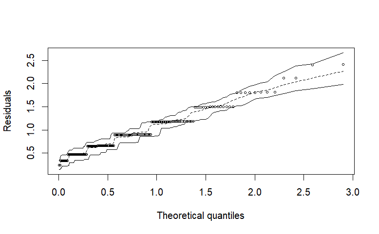

```r
model_food <- glm(
  price_binary ~ Food,
  data = nyc,
  family = binomial
)

hnp(model_food)
```

Some residuals are outside the envelope bands, so this model does not seem to fit the data perfectly.

### (b) Predictor: Service

```
Binomial model
```

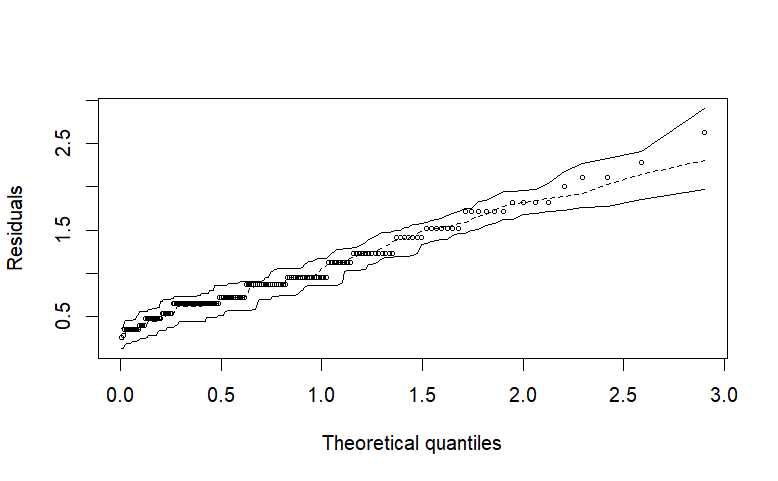

```r
model_service <- glm(
  price_binary ~ Service,
  data = nyc,
  family = binomial
)

hnp(model_service)
```

For this model, all points are inside the envelope bands, so we could say this model fits the data well.

### (c) Predictor: Decor

```
Binomial model
```

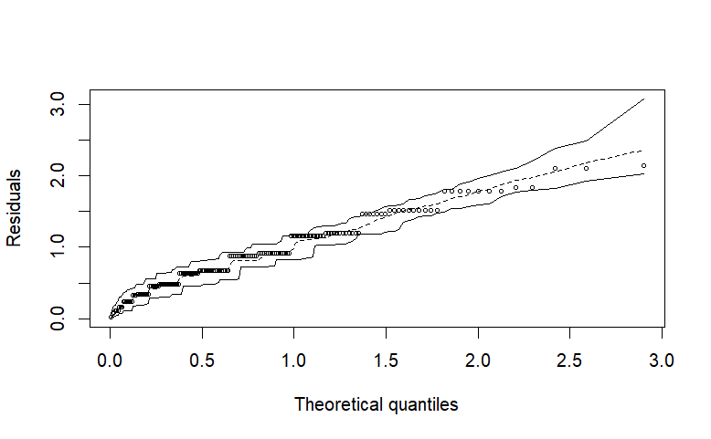

```r
model_decor <- glm(
  price_binary ~ Decor,
  data = nyc,
  family = binomial
)

hnp(model_decor)
```

Some residuals are outside the envelope bands, so this model does not seem to fit the data perfectly.

## Question 2

Use `stepAIC` to select the model with the lowest AIC.

```r
model_all <- glm(
  price_binary ~ Food + Decor + Service,
  data = nyc,
  family = binomial
)

stepAIC(model_all)
```

```
Start:  AIC=154.94
price_binary ~ Food + Decor + Service

          Df Deviance    AIC
- Service  1   147.00 153.00
<none>         146.94 154.94
- Food     1   153.16 159.16
- Decor    1   169.27 175.27

Step:  AIC=153
price_binary ~ Food + Decor

        Df Deviance    AIC
<none>       147.00 153.00
- Food   1   162.68 166.68
- Decor  1   176.04 180.04

Call:  glm(formula = price_binary ~ Food + Decor, family = binomial,
    data = nyc)

Coefficients:
(Intercept)         Food        Decor
   -19.2694       0.5132       0.5211

Degrees of Freedom: 167 Total (i.e. Null);  165 Residual
Null Deviance:      229.5
Residual Deviance: 147  AIC: 153
```

The function stepAIC has removed variable Service in the first step and has chosen the model with variables Food and Decor as the final model